# TOD report for San Fransico

Jingyi Cai

2022-09-21

TOD(transit-oriented development), means integrated urban places designed to bring people, activities, buildings, and public space together, with easy walking and cycling connection between them and near-excellent transit service to the rest of the city. Someone says taht TOD is a necessary foundation for long-term sustainability, equity, shared prosperity, and civil peace in cities. In this report, I chose San Francisco as the target city and explored whether San Franciscans are willing to pay for TOD through the relationship between rent and proximity of housing to transit. However, as the result shows, San Franciscans may not want to pay for TOD.

# 1.The process of data wrangling

In this process, I collect the data of San Francisco in 2009 and 2020. Most of the sources of the data comes from the ACS, and some of them comes from the website of the website of the BART.

## Load packages and functions, get API

```r
# Load Libraries

library(tidyverse)
library(tidycensus)
library(sf)
library(kableExtra)

options(scipen=999)
options(tigris_class = "sf")

source("https://raw.githubusercontent.com/urbanSpatial/Public-Policy-Analytics-Landing/master/functions.r")

palette5 <- c("#f0f9e8","#bae4bc","#7bccc4","#43a2ca","#0868ac")
```

```r
census_api_key("54e1504e7d4ea123055891fc53806c2ec3cfc0bb", overwrite = TRUE, install = TRUE)
```

## Working with ACS Data

### 2009 Census Data

Let’s Use `get_acs()`to get 2009 ACS data and rename them.

```r
tracts09 <-
  get_acs(geography = "tract",
          variables = c("B25026_001E","B02001_002E",
                        "B15001_050E","B15001_009E",
                        "B19013_001E", "B25058_001E",
                        "B06012_002E"),
          year=2009, state=06,
          county=075, geometry=TRUE) %>%
  st_transform('EPSG:2229')
```

```r
# Let's "spread" the data into wide form
tracts09 <-
  tracts09 %>%
  dplyr::select( -NAME, -moe) %>%
  spread(variable, estimate) %>%  #from long to wide data
  rename(TotalPop = B25026_001,
         Whites = B02001_002,
         FemaleBachelors = B15001_050,
         MaleBachelors = B15001_009,
         MedHHInc = B19013_001,
         MedRent = B25058_001,
         TotalPoverty = B06012_002)


# Let's create new rate variables using mutate
tracts09 <-
  tracts09 %>%
  mutate(pctWhite = ifelse(TotalPop > 0, Whites / TotalPop, 0),#if()is true, turn the next one
         pctBachelors = ifelse(TotalPop > 0, ((FemaleBachelors + MaleBachelors) / TotalPop), 0),
         pctPoverty = ifelse(TotalPop > 0, TotalPoverty / TotalPop, 0),
         year = "2009") %>%
  dplyr::select(-Whites,-FemaleBachelors,-MaleBachelors,-TotalPoverty)
```

However, I find that if add the Farallon Islands into selection, where there is no public transportation, the scale of the map will become pretty small. So, in order to make the report clearer, this study was conducted in San Francisco excluding Farallon Islands.

```r
tracts09 <- tracts09%>%
  filter(GEOID != "06075060400")
```

Tracts 2009 is now complete. Let’s grab 2020 tracts and do the same thing.

### 2020 Census Data

```r
tracts20 <-
  get_acs(geography = "tract",
          variables = c("B25026_001E","B02001_002E",
                        "B15001_050E","B15001_009E",
                        "B19013_001E","B25058_001E",
                        "B06012_002E"),
          year=2020, state=06, county=075,
          geometry=TRUE, output="wide") %>%
  st_transform('EPSG:2229') %>%
  rename(TotalPop = B25026_001E,
         Whites = B02001_002E,
         FemaleBachelors = B15001_050E,
         MaleBachelors = B15001_009E,
         MedHHInc = B19013_001E,
         MedRent = B25058_001E,
         TotalPoverty = B06012_002E) %>%
  dplyr::select(-NAME, -starts_with("B")) %>%
  mutate(pctWhite = ifelse(TotalPop > 0, Whites / TotalPop,0),
         pctBachelors = ifelse(TotalPop > 0, ((FemaleBachelors + MaleBachelors) / TotalPop),0),
         pctPoverty = ifelse(TotalPop > 0, TotalPoverty / TotalPop, 0),
         year = "2020") %>%
  dplyr::select(-Whites, -FemaleBachelors, -MaleBachelors, -TotalPoverty)
```

```r
tracts20 <- tracts20%>%
  filter(GEOID != "06075060400" & GEOID != "06075980401")
#Combine the 2009 and 2020 data into the same data frame.
allTracts <- rbind(tracts09,tracts20)
```

## Wrangling Transit Open Data

BART (Bay Area Rapid Transport) is similar to a short distance train system, and the BART lines link San Francisco to other cities and further away places. I download its geojson files of its stations from the website.

```r
#install.packages("geojsonio")
library(geojson)
#install.packages("geojsonsf")
library(geojsonsf)

station <- geojsonsf::geojson_sf("BART_Station(1).geojson") %>%
  st_transform('EPSG:2229')
```

## Relating Subway Stops and Tracts

```r
stationBuffers <-
  rbind(
    st_buffer(filter(station, City == "San Francisco"), 2640) %>%  #feet and mile
      mutate(Legend = "Buffer") %>%
      dplyr::select(Legend),
    st_union(st_buffer(filter(station, City == "San Francisco"), 2640)) %>%  #takelines together
      st_sf() %>%
      mutate(Legend = "Unioned Buffer"))

sanFrancisco <-
  filter(station, City == "San Francisco")
```

```r
buffer <- filter(stationBuffers, Legend=="Unioned Buffer")
```

### Make sure my way of selection

In this report, I choose the way of selecting centroids of the tracts because it captures a concise set of tracts without altering geometries. While well-reasoned, it is still subjective, and each choice will ultimately lead to different results. Such is the impact of scale problems in spatial analysis.

```r
selectCentroids <-
  st_centroid(tracts09)[buffer,] %>%
  st_drop_geometry() %>%
  left_join(., dplyr::select(tracts09, GEOID), by = "GEOID") %>%
  st_sf() %>%
  dplyr::select(TotalPop) %>%
  mutate(Selection_Type = "Select by Centroids")
```

### Get indicator Maps

In this progress, I can get the data of indicators of 2009 and 2020.

```r
allTracts.group <-
  rbind(
    st_centroid(allTracts)[buffer,] %>%
      st_drop_geometry() %>%
      left_join(allTracts) %>%
      st_sf() %>%
      mutate(TOD = "TOD"),
    st_centroid(allTracts)[buffer, op = st_disjoint] %>%
      st_drop_geometry() %>%
      left_join(allTracts) %>%
      st_sf() %>%
      mutate(TOD = "Non-TOD")) %>%
  mutate(MedRent.inf = ifelse(year == "2009", MedRent * 1.14, MedRent))
```

## Figure out my final TOD Indicator Tables

The previous numbers are not final results, so we still need to figure out the final results.

```r
allTracts.Summary <-
  st_drop_geometry(allTracts.group) %>%
  group_by(year, TOD) %>%
  summarize(Rent = mean(MedRent, na.rm = T),
            Population = mean(TotalPop, na.rm = T),
            Percent_White = mean(pctWhite, na.rm = T),
            Percent_Bach = mean(pctBachelors, na.rm = T),
            Percent_Poverty = mean(pctPoverty, na.rm = T))
```

# 2.Four small-multiple (2009 & 2017+) visualizations comparing four selected Census variables across time and space (TOD vs. non-TOD).

```r
#make sure the outline of the selected areas.
outline <- st_union(selectCentroids)
```

## The comparion of rent between TOD and non-TOD

The first variable I select is the rent, which is one of the most obvious indicators expressing people’s willingness to pay for TOD. In 2009, rents in TOD areas were not higher than in non-TOD areas, and in 2020 rents in TOD areas are even lower than in non-TOD areas.

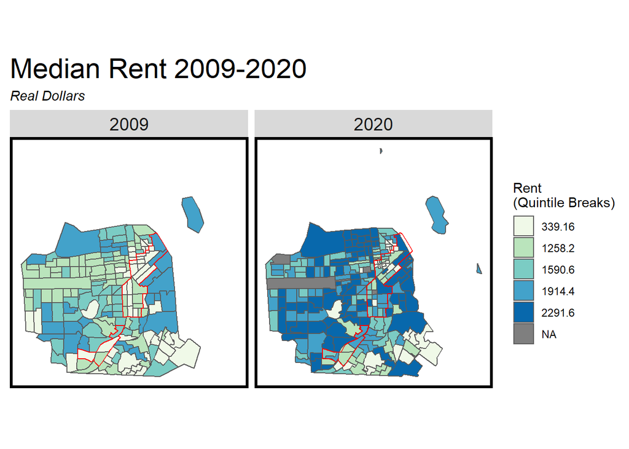

```r
 ggplot(allTracts.group)+

    geom_sf(aes(fill = q5(MedRent.inf))) +
    geom_sf(data = outline, fill = "transparent", color = "red")+
    scale_fill_manual(values = palette5,
                      labels = qBr(allTracts.group, "MedRent.inf"),
                      name = "Rent\n(Quintile Breaks)") +
    labs(title = "Median Rent 2009-2020", subtitle = "Real Dollars") +
    facet_wrap(~year)+
    mapTheme() +
    theme(plot.title = element_text(size=22))
```

## The comparion of total population between TOD and non-TOD

The second variable I choose is the population of different districts. If more people love TOD, they may choose to live beside them. In 2009 and 2020,the number of people in TOD areas is not very different from non-TOD areas.

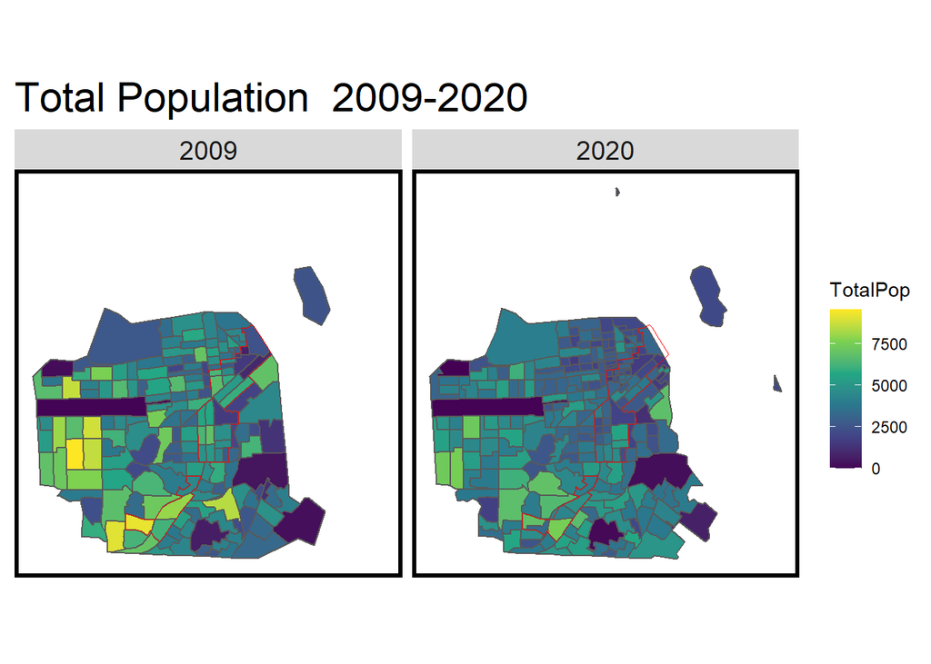

```r
ggplot(allTracts.group)+
    #geom_sf(data = st_union(tracts09))+
    geom_sf(aes(fill = TotalPop)) +
    labs(title = "Total Population  2009-2020") +
    geom_sf(data = st_union(selectCentroids), fill = "transparent", color = "red", size = 0.3)+
    facet_wrap(~year)+
    scale_fill_viridis_c() +
    mapTheme() +
    theme(plot.title = element_text(size=22))
```

## The comparion of percentage of poverty between TOD and non-TOD

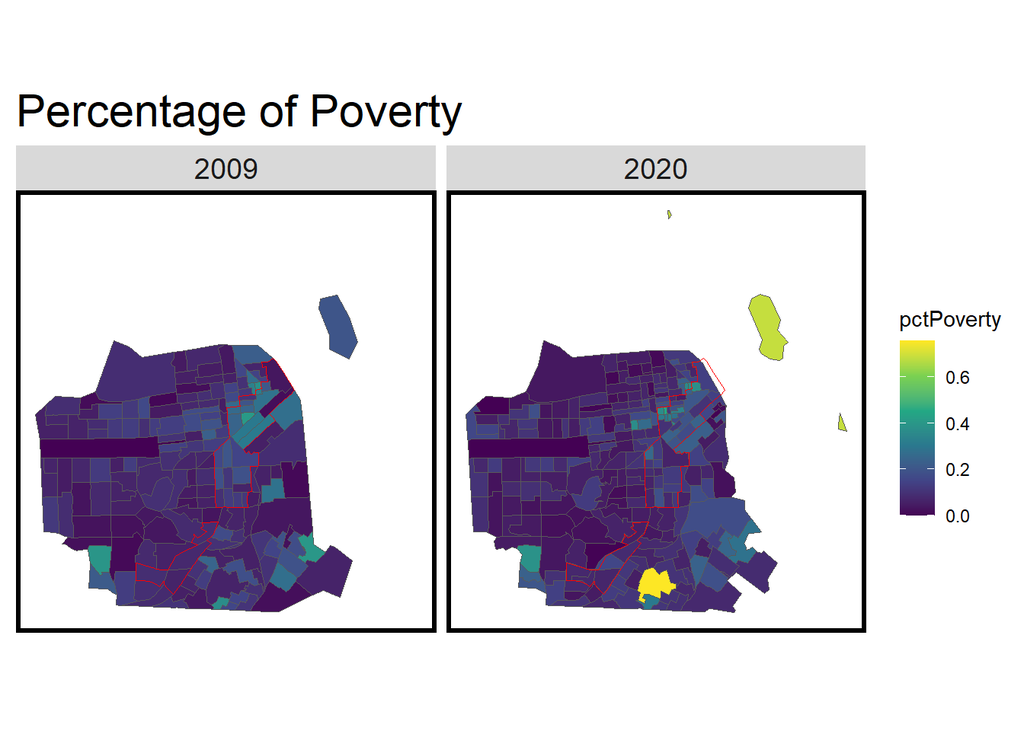

```r
ggplot(allTracts.group)+
    #geom_sf(data = st_union(tracts09))+
    geom_sf(aes(fill = pctPoverty),size = 0.1) +
    labs(title = "Percentage of Poverty") +
    geom_sf(data = st_union(selectCentroids), fill = "transparent", color = "red", size = 0.3)+
    facet_wrap(~year)+
    scale_fill_viridis_c() +
    mapTheme() +
    theme(plot.title = element_text(size=22))
```

## The comparion of percentage of bachelors between TOD and non-TOD

The percentage of bachelors can reflect education level. In 2009, the percentage of bachelors is low in both TOD and non-TOD places. But in 2020, the percentage of bachelors rised in both TOD and non-TOD places.

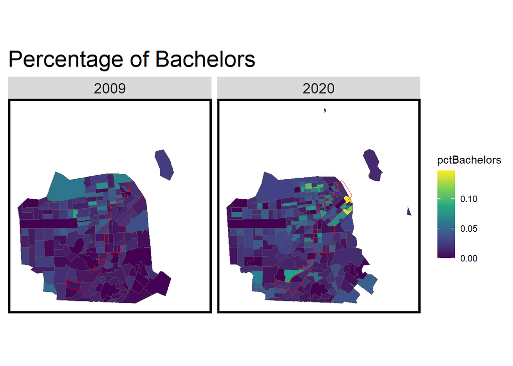

```r
ggplot(allTracts.group)+
    #geom_sf(data = st_union(tracts09))+
    geom_sf(aes(fill = pctBachelors),size = 0.1) +
    labs(title = "Percentage of Bachelors") +
    geom_sf(data = st_union(selectCentroids), fill = "transparent", color = "red", size = 0.3)+
    facet_wrap(~year)+
    scale_fill_viridis_c() +
    mapTheme() +
    theme(plot.title = element_text(size=22))
```

# 3.Grouped bar plot making these same comparisons.

For this study, I compared four selected Census variables across time and space.We can know more directly the difference in values between TOD and non-TOD areas.

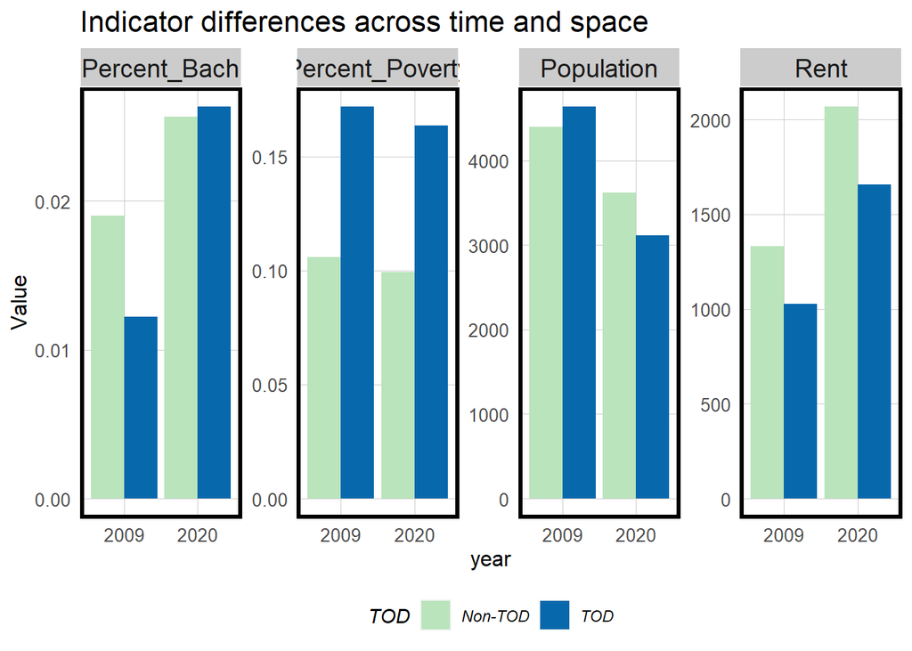

```r
allTracts2.Summary <-allTracts.Summary[,-5]
allTracts2.Summary %>%
  gather(Variable, Value, -year, -TOD) %>%
  ggplot(aes(year, Value, fill = TOD)) +
  geom_bar(stat = "identity", position = "dodge") +
  facet_wrap(~Variable, scales = "free", ncol=5) +
  scale_fill_manual(values = c("#bae4bc", "#0868ac")) +
  labs(title = "Indicator differences across time and space") +
  plotTheme() + theme(legend.position="bottom")
```

# 4.We can also make a table to make these same comparisons.

```r
kable(allTracts2.Summary) %>%
  kable_styling() %>%
  footnote(general_title = "\n",
           general = "Table 2.2")
```

| year | TOD | Rent | Population | Percent_Bach | Percent_Poverty |
| --- | --- | --- | --- | --- | --- |
| 2009 | Non-TOD | 1333.048 | 4404.279 | 0.0189939 | 0.1059576 |
| 2009 | TOD | 1028.750 | 4641.857 | 0.0122227 | 0.1719494 |
| 2020 | Non-TOD | 2069.042 | 3625.851 | 0.0256487 | 0.0992397 |
| 2020 | TOD | 1657.935 | 3116.750 | 0.0263494 | 0.1635826 |

Table 2.2

# 5. The relation between rent and the distance station

```r
#make buffers of the stations
stationBuffers <-
  rbind(
    st_buffer(sanFrancisco, 2640) %>%
      mutate(Legend = "Buffer") %>%
      dplyr::select(Legend, Name))
```

```r
#intersect the buffer of the station with tracts
tractClipped20 <-
  st_intersection(stationBuffers, tracts20) %>%
  dplyr::select(TotalPop,MedRent,Name) %>%
  mutate(year = 2020)

tractClipped09 <-
  st_intersection(stationBuffers, tracts09) %>%
  dplyr::select(TotalPop,MedRent,Name) %>%
  mutate(year = 2009)
```

```r
tractGrouped09 <- tractClipped09 %>%
  group_by(Name,year) %>%
  summarize("Average Median Rent" = mean(MedRent),
            "TotalPop" = sum(TotalPop))
tractGrouped20 <- tractClipped20 %>%
  group_by(Name, year) %>%
  summarize("Average Median Rent" = mean(MedRent),
            "TotalPop" = sum(TotalPop))
```

```r
intersection_0920 <- rbind(tractGrouped09,tractGrouped20)
centers = st_centroid(intersection_0920)
```

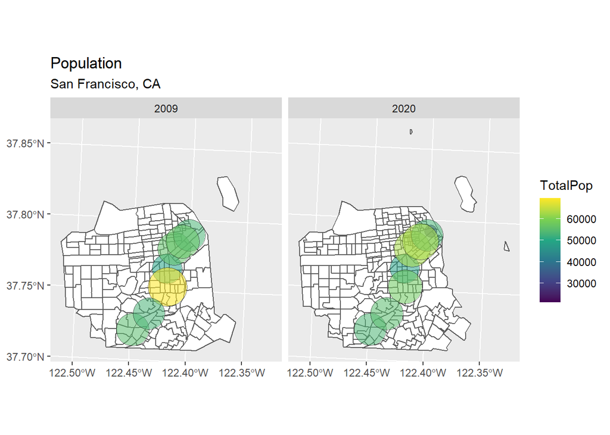

```r
ggplot() +
  geom_sf(data = tracts09, fill = "white") +
  geom_sf(data = tracts20, fill = "white") +
  geom_sf(data = centers, aes(size = TotalPop,fill = TotalPop,alpha = 1),shape = 21,
          show.legend = "point") +
  labs(title = "Population", subtitle = "San Francisco, CA") +
  guides(alpha = FALSE)+
  guides(size = FALSE)+
  scale_fill_viridis_c() +
  facet_wrap(~year)+

  scale_size_continuous(range = c(0.1, 15))
```